# Algorítmo de Gibbs: Modelo Poisson com prioris (conjugadas) em dois estágios

## Modelo e expressões

Seja um modelo com estrutura hierárquica no qual assume-se a distribuição $Poisson(\lambda)$ para as observações, priori $Gamma(a, \beta)$ com $a$ considerado aqui constante e hiperpriori $GammaInversa(c, d)$ para $\beta$. Neste modelo não é possível amostrar diretamente da posteriori e obter as marginais em forma fechada. Implementar o algoritmo de Gibbs.

$$\begin{align*}
Y|\lambda &\sim {\rm Po}(\lambda) \\
\lambda|\beta &\sim {\rm Ga}(a, \beta) \\
\beta &\sim {\rm IGa}(c,d)
\end{align*}$$

Neste modelo os parâmetros são $\theta = (\lambda, \beta)^{\prime}$ e $(a, c, d)$ são constantes conhecidas/fixadas.

A função de probabilidade para uma observação $y_i$ é
$$f(y; \lambda) = \frac{\exp\{-\lambda\} \lambda^{y_i}}{y_i!}$$
e a verossimilhança para as observações, consideradas condicionalmente independentes dado $\lambda$:
$$L(\lambda; y) = \frac{\exp\{-n\lambda\} \lambda^{\sum{y_i}}}{\prod y!}$$
As prioris são:
$$\begin{align*}
f(\lambda|\beta) &= \frac{1}{\beta^a \Gamma(a)} \lambda^{a-1} \exp\{-\lambda/\beta\}\\
f(\beta) &= \frac{1}{d^c \Gamma(c)} \beta^{-c-1} \exp\{-1/d\beta\}
\end{align*}$$

A posteriori é obtida por
$$f(\lambda,\beta|y) = \frac{f(\lambda,\beta,y)}{f(y)} \propto
f(\lambda,\beta,y) = f(y|\lambda,\beta)f(\lambda|\beta)f(\beta) =
f(y|\lambda)f(\lambda|\beta)f(\beta)$$
Na expressão anterior, a estrutura de independência condicional do modelo implica que $f(y|\lambda,\beta) = f(y|\lambda)$.

## Códigos em R para o Exemplo

Inicialmente vamos definir duas funções auxiliares, uma para densidade da distribuição $Gama-Inversa(a,b)$ e outra que retorna a esperança e variância desta distribuição.

```r
dinvgamma <- function(x, shape, scale) dgamma(1/x, shape=shape, scale=scale)/x^2
##
EVIG <- function(a,b){
    E <- ifelse(a > 1, 1/(b * (a-1)), "não pode ser calculada para este valor de a")
    V  <- ifelse(a > 2, 1/((b^2) * ((a-1)^2) * (a-2)), "não pode ser calculada para este valor de a")
    return(c(E,V))
}
```

Consideramos neste exemplo $a=4,5$, $c=2,2$ e $d=0,6$. Na próxima figura pode-se visualizar a priori para $\beta$. Note que para $\lambda$ o modelos define apenas a condicional $\lambda|\beta$ mas pode-se obter a marginal.
$$\begin{align*}
f(\lambda) &= \int f(\lambda, \beta) {\rm d}\beta = \int f(\lambda|\beta) f(\beta) {\rm d}\beta.
\end{align*}$$

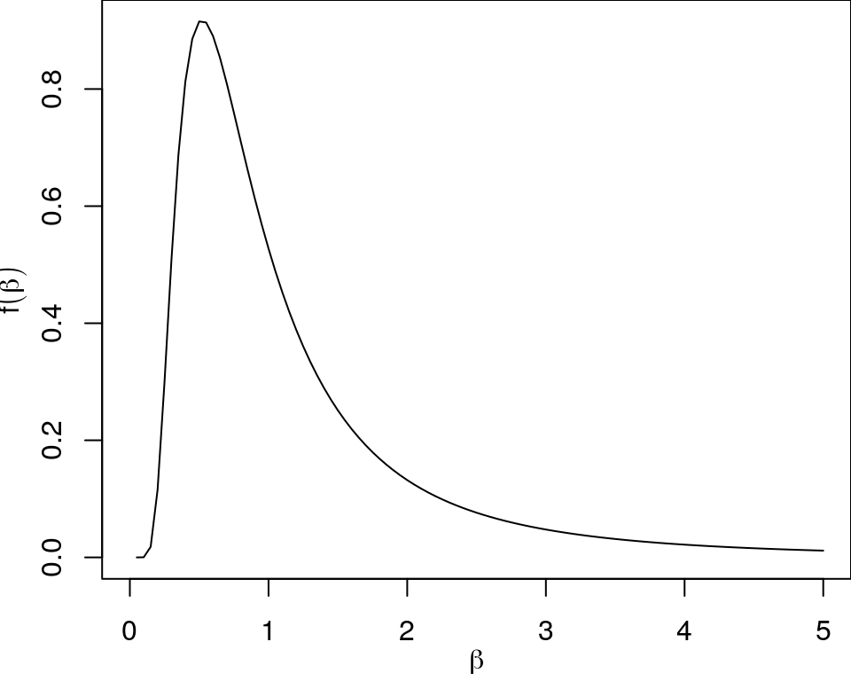

```r
par(mar=c(3,3,0,0), mgp=c(2,1,0))
curve(dinvgamma(x, shape=2.2, scale=0.6),
      from=0, to=5, xlab=expression(beta), ylab=expression(f(beta)))
```

A seguir será simulado um conjunto de dados com 50 observações. Para isto são inicialmente fixadas as constantes no modelo. Na sequencia simulam-se valores de $\beta$ e para cada um deles simula-se um valor de $\lambda$. Finalmente simula-se, respectivamente, uma observação da variável resposta $Y$.

```r
set.seed(2018)
ctes <- list(a=4.5, c=2.2, d=0.6, n=50)
with(ctes, EVIG(c, d))
```

```
## [1] 1.388889 9.645062
```

```r
betas <- with(ctes, 1/rgamma(n, shape=c, scale=d))
c(mean(betas),var(betas))
```

```
## [1] 1.385987 1.247596
```

```r
lambdas <- with(ctes, rgamma(n, shape=a, scale=betas))
(ctes$y <- rpois(ctes$n, lambda=lambdas))
```

```
##  [1]  5 12  4  1  4  3  0 11  1  5  4  3 14  3  4  7 10  5  3  5  9  2 13
## [24] 18  5  2 10  2  4 11  2  4  3  2 13  6 35  0  3  1 13  2  8  4  1  0
## [47]  0  7  4  4
```

A seguir temos estatísticas dscritivas do dados. Notamos que a média é bem inferior à variância, caracterizando uma sobredispersão. No gráfico dos dados (linhas escura) vê-se claramente qua a distribuição Poisson (linhas vermelhas) com parâmetro constante não se ajusta bem aos dados.

```r
with(ctes, c(media=mean(y), var=var(y)))
```

```
##    media      var
##  5.84000 35.97388
```

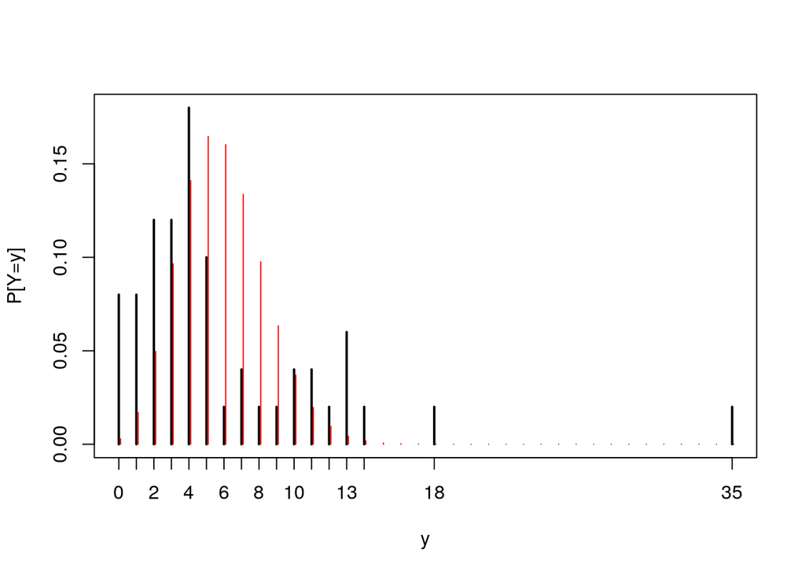

```r
with(ctes, plot(prop.table(table(y)), type="h", ylab="P[Y=y]"))
with(ctes,lines((0:max(y))+0.1, dpois(0:max(y), lambda=mean(y)), type="h", col=2))
```

Vamos agora implementar um amostrador de Gibbs para obter amostras da posteriori. Serão tomadas 11.000 simulações.

```r
ctes$sumY <- sum(ctes$y)
N <- 11000
beta.sam <- lambda.sam <- numeric(N)
beta.sam[1] <- lambda.sam[1] <- 10 ## valores iniciais
{
for(i in 2:N){
    beta.sam[i] <- with(ctes, 1/rgamma(1, shape=a+c, scale=d/(d*lambda.sam[i-1]+1)))
    lambda.sam[i] <- with(ctes, rgamma(1, shape=a+sumY, scale=beta.sam[i]/(n*beta.sam[i]+1)))
}}
```

A seguir temos a visualização das cadeias para uma inspeção visual inicial.

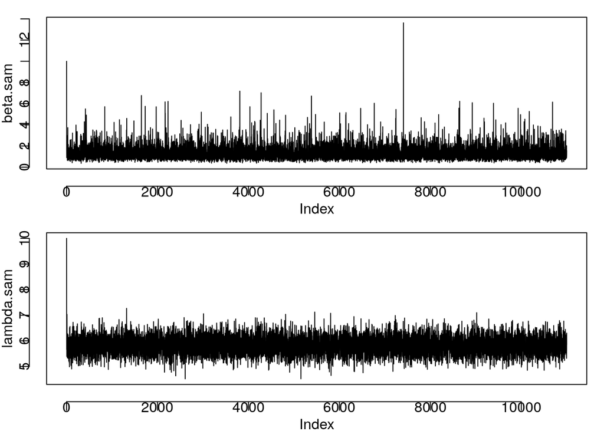

```r
par(mfrow=c(2,1), mar=c(2.7,2.7,1,1), mgp=c(1.8,0.8,1))
plot(beta.sam, type="l")
plot(lambda.sam, type="l")
```

Entretanto é preciso atentar para a necessidade de aquecimento (//burn-in//) da cadeia. Ou seja, amostras iniciais podem não ser represetnativas da distribuição estacionária. Serão agora descartadas 1.000 como aquecimento da cadeia (//burn-in//).

Além disto iremos também proceder um raleamento (//thining//) armazenando apenas uma a cada dez amostras uma vez que as cedeias geradas tendem a ter muita autocorrelação entre as amostras o que implica em redundância de informação e uso desnecessário de memória.

```r
B <- 1000
beta.sam <- beta.sam[-(1:B)]
lambda.sam <- lambda.sam[-(1:B)]
beta.sam <- beta.sam[seq(1,N-B, by=10)]
lambda.sam <- lambda.sam[seq(1,N-B, by=10)]
```

A seguir temos a visualização das cadeias para uma nova inspeção visual.

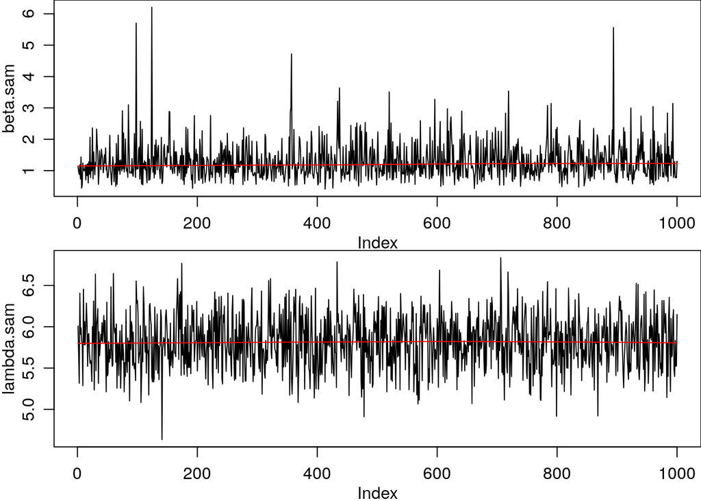

```r
par(mfrow=c(2,1), mar=c(2.7,2.7,0,0), mgp=c(1.8,0.8,0))
plot(beta.sam, type="l"); lines(lowess(beta.sam), col=2)
plot(lambda.sam, type="l"); lines(lowess(lambda.sam), col=2)
```

Não se percebe nenhum problema obvio com as cadeias mas nota-se a posteriori de $\beta$ parece ter um comportamento assimétrico. Vamos então examinar a cadeia para escala logarítmica.

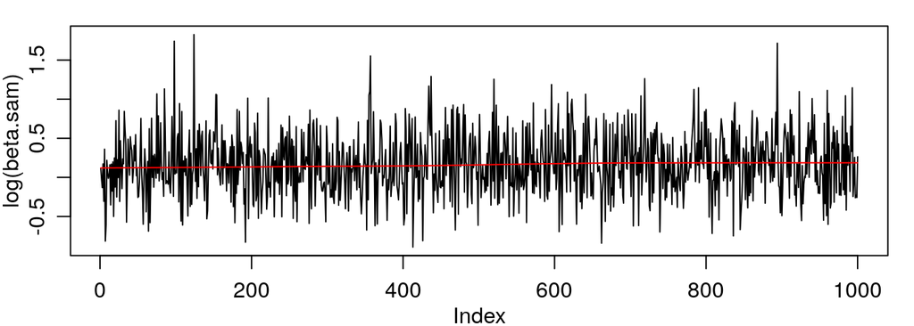

```r
par(mfrow=c(1,1), mar=c(2.7,2.7,1,1), mgp=c(1.8,0.8,0))
plot(log(beta.sam), type="l"); lines(lowess(log(beta.sam)), col=2)
```

E vamos também verificar a autocorrelação após o raleamento.

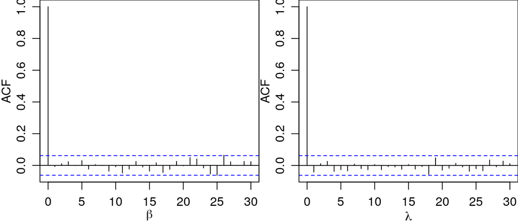

```r
par(mfrow=c(1,2), mar=c(2.7,2.7,0,0), mgp=c(1.8,0.8,0))
acf(beta.sam, xlab=expression(beta))
acf(lambda.sam, xlab=expression(lambda))
```

Estas análiss iniciais não apontam problemas óbvios e parece que temos uma boa amostra. Entretanto uma análise mais cuidadosa deveria incluir testes de diagnóstico de convergência, possivelmente com a obtenção de não apenas uma cadeia. Não vamos abordar estes testes aqui e seguiremos com a análise a partir da amostra obtida.

A seguir visualiza-se as amostras das distribuições marginais. Os valores indicados nos eixos são os gerados na simulação dos dados.

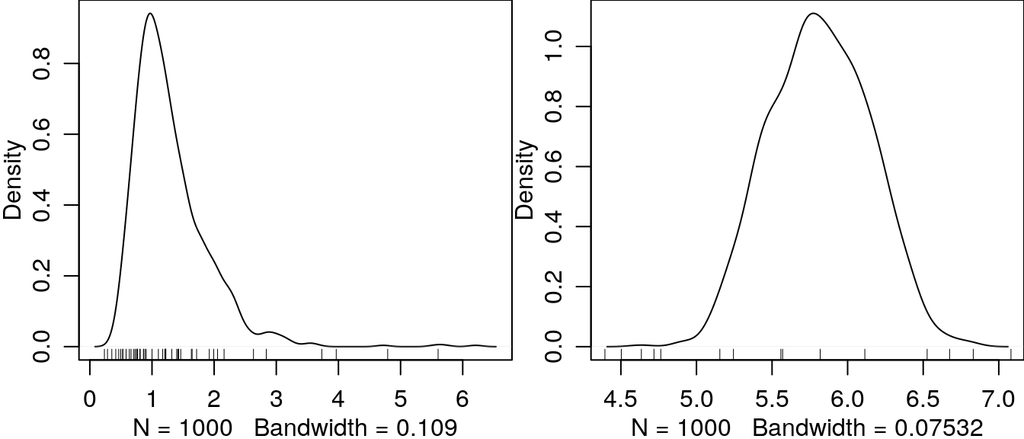

```r
par(mfrow=c(1,2), mar=c(2.7,2.7,0,0), mgp=c(1.8,0.8,0))
plot(density(beta.sam), main=""); rug(betas)
plot(density(lambda.sam), main=""); rug(lambdas)
```

A seguir visualiza-se as amostras da conjunta com $\beta$ na escala original e logarítmica.

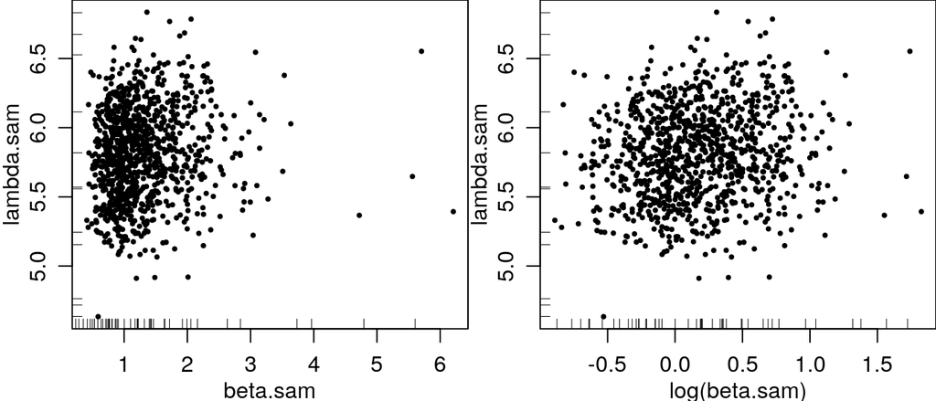

```r
par(mfrow=c(1,2), mar=c(2.7,2.7,0,0), mgp=c(1.8,0.8,0))
plot(beta.sam, lambda.sam, pch=19, cex=0.4); rug(betas, side=1); rug(lambdas, side=2)
plot(log(beta.sam), lambda.sam, pch=19, cex=0.4); rug(log(betas), side=1); rug(lambdas, side=2)
```

Resumos dos dados e das posterioris dos parâmetros.

```r
summary(ctes$y)
```

```
##    Min. 1st Qu.  Median    Mean 3rd Qu.    Max.
##    0.00    2.00    4.00    5.84    7.75   35.00
```

```r
summary(betas)
```

```
##    Min. 1st Qu.  Median    Mean 3rd Qu.    Max.
##  0.2341  0.7331  1.1373  1.3860  1.5907  5.6039
```

```r
summary(beta.sam)
```

```
##    Min. 1st Qu.  Median    Mean 3rd Qu.    Max.
##  0.4102  0.9008  1.1640  1.2989  1.5469  6.2081
```

```r
summary(lambdas)
```

```
##    Min. 1st Qu.  Median    Mean 3rd Qu.    Max.
##  0.1716  2.7200  4.0948  5.8029  6.4230 40.6322
```

```r
summary(lambda.sam)
```

```
##    Min. 1st Qu.  Median    Mean 3rd Qu.    Max.
##   4.634   5.569   5.809   5.814   6.053   6.835
```

```r
dbetapost <- function(x, a, c, d, soma, n, log=FALSE){
res <- lgamma(a+soma+1) + (a+soma+1)*(log(x)-log(n*x+1))-(a+c+1)*log(x) - 1/(d*x)
if(log) return(res) else return(exp(res))
}
dlambdapost <- function(x, a, c, d, soma, n, log=FALSE){
res <- lgamma(a+c) + (a+c)*(log(d)-log(d*x-1))+(s+soma)*log(x) - n*x
if(log) return(res) else return(exp(res))
}
```